# First Look at NYPD CCRB data

Andriy Koval

Kyle Belanger

This report records the initial exploration of the NYPD CCRB data as reported by the ProPublica ([source](https://www.propublica.org/datastore/dataset/civilian-complaints-against-new-york-city-police-officers)).

The report also records the data cleaning actions motivated by the initial exploration.

# Environment

This section offers technical detail on the environment and data preparation. Non-technical readers should feel free to skip.

```r
library(tidyverse)
library(glue)
library(scales)
```

```r
# knitr::opts_knit$set(base.dir = "../../")
source("./scripts/common-functions.R")
```

```r
# path_input <- "../../data-unshared/derived/dto.rds"
path_input <- "./data-unshared/derived/dto_propublica.rds"
# Taps into https://projects.propublica.org/nypd-ccrb/
# https://github.com/rtrent/NYPDCivilianComplaintReviewBoard)
#set default ggplot theme
ggplot2::theme_set(
  ggplot2::theme_bw(
  )+
    theme(
      strip.background = element_rect(fill="grey90", color = NA)
    )
)

mos_rank_order <- c("Police Officer", "Detective", "Sergeant", "Lieutenant",
                    "Captain", "Deputy Inspector", "Inspector","Chief")

ethnicity5 <- c("White","Black","Hispanic","Other", "(Missing)")
gender4 <- c("Male","Female","Other","(Missing)")

counts_and_percent <- function(d,varnames){
  dt <- ds2 %>%
    group_by(.dots = varnames) %>%
    count() %>%
    ungroup() %>%
    mutate(pct = scales::percent(n/sum(n), accuracy=.1))
  return(dt)
}
# How to use
# counts_and_percent(ds2, c("rank_incident","rank_now")) %>% neat()
```

```r
ds0 <- readr::read_rds(path_input)
# metadata <- readr::read_csv("../../data-public/metadata/better-labels.csv")
metadata <- readr::read_csv("./data-public/metadata/better-labels.csv")

# ds0 %>% glimpse()
```

```r
skimr::skim(ds0)
```

Data summary

| Name | ds0 |
| --- | --- |
| Number of rows | 33358 |
| Number of columns | 27 |
| _______________________ |  |
| Column type frequency: |  |
| character | 17 |
| numeric | 10 |
| ________________________ |  |
| Group variables | None |

**Variable type: character**

| skim_variable | n_missing | complete_rate | min | max | empty | n_unique | whitespace |
| --- | --- | --- | --- | --- | --- | --- | --- |
| first_name | 0 | 1.00 | 2 | 10 | 0 | 1217 | 0 |
| last_name | 0 | 1.00 | 2 | 18 | 0 | 2835 | 0 |
| command_now | 0 | 1.00 | 2 | 7 | 0 | 415 | 0 |
| command_at_incident | 1544 | 0.95 | 2 | 7 | 0 | 361 | 0 |
| rank_abbrev_incident | 0 | 1.00 | 2 | 3 | 0 | 18 | 0 |
| rank_abbrev_now | 0 | 1.00 | 2 | 3 | 0 | 20 | 0 |
| rank_now | 0 | 1.00 | 7 | 22 | 0 | 8 | 0 |
| rank_incident | 0 | 1.00 | 7 | 22 | 0 | 8 | 0 |
| mos_ethnicity | 0 | 1.00 | 5 | 15 | 0 | 5 | 0 |
| mos_gender | 0 | 1.00 | 1 | 1 | 0 | 2 | 0 |
| complainant_ethnicity | 4464 | 0.87 | 5 | 15 | 0 | 8 | 0 |
| complainant_gender | 4195 | 0.87 | 4 | 21 | 0 | 6 | 0 |
| fado_type | 0 | 1.00 | 5 | 18 | 0 | 4 | 0 |
| allegation | 1 | 1.00 | 4 | 40 | 0 | 115 | 0 |
| contact_reason | 199 | 0.99 | 5 | 58 | 0 | 53 | 0 |
| outcome_description | 56 | 1.00 | 12 | 36 | 0 | 23 | 0 |
| board_disposition | 0 | 1.00 | 10 | 40 | 0 | 11 | 0 |

**Variable type: numeric**

| skim_variable | n_missing | complete_rate | mean | sd | p0 | p25 | p50 | p75 | p100 | hist |
| --- | --- | --- | --- | --- | --- | --- | --- | --- | --- | --- |
| unique_mos_id | 0 | 1.00 | 18169.91 | 9566.32 | 2 | 9671.00 | 19215 | 25412 | 36374 | ▆▆▇▇▃ |
| shield_no | 0 | 1.00 | 6451.61 | 7945.64 | 0 | 1089.00 | 3691 | 7155 | 31977 | ▇▂▁▁▁ |
| complaint_id | 0 | 1.00 | 23905.06 | 11954.43 | 517 | 13684.75 | 25132 | 34252 | 43703 | ▅▆▆▇▇ |
| month_received | 0 | 1.00 | 6.32 | 3.36 | 1 | 3.00 | 6 | 9 | 12 | ▇▆▅▆▇ |
| year_received | 0 | 1.00 | 2010.73 | 6.03 | 1985 | 2007.00 | 2012 | 2016 | 2020 | ▁▁▃▇▇ |
| month_closed | 0 | 1.00 | 6.47 | 3.34 | 1 | 4.00 | 6 | 9 | 12 | ▇▆▆▆▇ |
| year_closed | 0 | 1.00 | 2011.53 | 6.09 | 1985 | 2008.00 | 2013 | 2016 | 2020 | ▁▁▂▆▇ |
| mos_age_incident | 0 | 1.00 | 32.35 | 6.04 | 20 | 28.00 | 31 | 36 | 60 | ▅▇▃▁▁ |
| complainant_age_incident | 4812 | 0.86 | 32.48 | 28.41 | -4301 | 23.00 | 30 | 41 | 101 | ▁▁▁▁▇ |
| precinct | 24 | 1.00 | 64.37 | 31.45 | 0 | 43.00 | 67 | 81 | 1000 | ▇▁▁▁▁ |

```r
ds0 %>% pryr::object_size()
```

```
7.49 MB
```

```r
# ds1 - adjust the rows
ds1 <- ds0 %>%
  mutate(
    date_received = as.Date(paste0(year_received,"-",month_received,"-15"))
    ,date_closed = as.Date(paste0(year_closed,"-",month_closed,"-15"))
    ,mos_yob = (year_received - mos_age_incident)
    ,complainant_yob = (year_received - complainant_age_incident)
  ) %>%
  mutate(
    complainant_ethnicity = replace_na(complainant_ethnicity, "(Missing)")
    ,complainant_ethnicity5 = fct_recode(
      complainant_ethnicity,
      "Other" = "American Indian"
      ,"Other" = "Asian"
      ,"Other" = "Other Race"
      ,"(Missing)" = "Refused"
      ,"(Missing)" = "Unknown"
    ) %>% fct_relevel(ethnicity5)
    ,mos_gender = fct_recode(mos_gender, "Female"="F", "Male"="M")
    ,complainant_gender = replace_na(complainant_gender,"(Missing)")
    ,complainant_gender4 = fct_recode(complainant_gender,
                                        "Female" = "Female"
                                        ,"Male" = "Male"
                                        ,"Other" = "Gender non-conforming"
                                        ,"Other" = "Transman (FTM)"
                                        ,"Other" = "Transwoman (MTF)"
                                        ,"(Missing)" = "Not described"
                                        ) %>% fct_relevel(gender4)
    ,complainant_age_incident = ifelse(complainant_age_incident < 10,NA,complainant_age_incident)

  ) %>%
  mutate_at(
    c("complainant_ethnicity","mos_ethnicity"), factor
  ) %>%
   tidyr::separate(board_disposition,into = c("disposition", "penalty"), sep = " \\(", remove = FALSE) %>%
  mutate(
    penalty = str_remove(penalty, "\\)$")
    ,disposition = fct_relevel(disposition, "Exonerated","Unsubstantiated","Substantiated")
  ) %>%
  mutate(
    rank_now = fct_recode(
      rank_now,
      "Chief" = "Chiefs and other ranks"
    ) %>%
      fct_relevel(mos_rank_order)
    ,rank_incident = fct_recode(
      rank_incident,
      "Chief" = "Chiefs and other ranks"
    ) %>%
      fct_relevel(mos_rank_order)

  )
  # select(-c("year_received","month_received","year_closed","month_closed"))

# ds1 %>% group_by(board_disposition) %>% count() %>% arrange(desc(n))
# ds1 %>% group_by(disposition) %>% count()
# ds1 %>% group_by(penalty) %>% count()

# ds1 %>% glimpse()
```

```r
# ds2 - adjust the columns
ds2 <- ds1 %>%
  select(
  # MOS - Member of Service
    unique_mos_id            #  Unique ID of the officer
    ,mos_ethnicity           #
    ,mos_gender              #
    ,mos_age_incident        #
    ,mos_yob                 # Year of birth
    ,rank_now                # Officer's rank as of July 2020
    ,rank_incident           #  --- at the time of the incident
    ,rank_abbrev_now         # Greater granularity of rank_now
    ,rank_abbrev_incident    # Greater granularity of rank_incident
    ,command_now             # Officer's command assignment as of July 2020
    ,command_at_incident     # --- at the time of the incident
    ,first_name
    ,last_name
    ,shield_no
  # Complainant
    ,complainant_ethnicity
    ,complainant_ethnicity5   # collapsed into 5 categories
    ,complainant_gender       # original values
    ,complainant_gender4      # Collapsed into 5 categories
    ,complainant_age_incident # less than 10 converted to NA
    ,complainant_yob          # year of birth
  # Complaint
    ,complaint_id
    ,date_received           # transformed from year + month (15th of the month)
    ,date_closed             # transformed from year + month (15th of the month)
    ,fado_type               # Top-level category of complaint
    ,allegation              # Specific category of complaint
    ,precinct
    ,board_disposition       # Finding disposition
    ,disposition             # Decision        (part of board_disposition)
    ,penalty                 # Penalty applied (part of board_disposition)
  # Contact ( between MOS and the complanant)
    ,contact_reason
    ,outcome_description     # Contact outcome
  )
```

# Data

This data was obtained by [ProPublica](https://projects.propublica.org/nypd-ccrb/) through a records request made to the CCRB. It includes fully investigated allegations only for officers who were members of the department as of late June 2020 and against whom the CCRB has substantiated at least one allegation. [Read More](https://projects.propublica.org/nypd-ccrb/#about)

Note that data reported by [NY Civil Liberty Union](https://github.com/new-york-civil-liberties-union/NYPD-Misconduct-Complaint-Database) contains about 10 times more records (`323,911`) than ProPublica’s (`33,358`) data presented here. One way to think about the difference between these two data sets is to take CLU as as the universe of all allegations registerd, while ProPublica’s would represent the universe of confirmed offenders.

# Variables

We grouped the inital variables according to entity for which they store information

```r
metadata %>%
  group_by(entity) %>%
  summarize(n_variables = n_distinct(item_name)) %>%
  arrange(desc(entity)) %>%
  neat()
```

| entity | n_variables |
| --- | --- |
| officer | 13 |
| contact | 2 |
| complaint | 9 |
| complainant | 4 |

```r
metadata %>%
  filter(entity == "officer") %>%
  arrange(desc(entity), item_name) %>%
  select(entity,item_name, item_description, item_label) %>%
  neat()
```

| entity | item_name | item_description | item_label |
| --- | --- | --- | --- |
| officer | command_at_incident | Officer’s command assignment at the time of the incident | Command at Incident |
| officer | command_now | Officer’s command assignment as of July 2020 | Command Current |
| officer | first_name | Officer’s first name | First Name |
| officer | last_name | Officer’s last name | Last Name |
| officer | mos_age_incident | Officer’s age at time of incident | MOS Age |
| officer | mos_ethnicity | Officer’s ethnicity | MOS Ethnicity |
| officer | mos_gender | Officer’s gender | MOS Gender |
| officer | mos_yob | Officer’s Year of Birth | Year of Birth (MOS) |
| officer | rank_abbrev_incident | Officer’s rank at the time of the incident, abbreviation | Rank at Incident (abbr) |
| officer | rank_abbrev_now | Officer’s rank as of July 2020, abbreviation | Rank Now (abbr) |
| officer | rank_incident | Officer’s rank at the time of the incident | Rank at Incident |
| officer | rank_now | Officer’s rank as of July 2020 | Rank Now |
| officer | unique_mos_id | unique ID of the officer (“member of service”) | ID MOS |

```r
metadata %>%
  filter(entity == "complainant") %>%
  arrange(desc(entity), item_name) %>%
  select(entity,item_name, item_description, item_label) %>%
  neat()
```

| entity | item_name | item_description | item_label |
| --- | --- | --- | --- |
| complainant | complainant_age_incident | Complainant’s age at time of incident | Age |
| complainant | complainant_ethnicity | Complainant’s ethnicity | Ethnicity |
| complainant | complainant_gender | Complainant’s gender | Gender |
| complainant | complainant_yob | Complainant’s Year of Birth | Year of Birth (C) |

```r
metadata %>%
  filter(entity == "complaint") %>%
  arrange(desc(entity), item_name) %>%
  select(entity,item_name, item_description, item_label) %>%
  neat()
```

| entity | item_name | item_description | item_label |
| --- | --- | --- | --- |
| complaint | allegation | Specific category of complaint | Compaint Subtype |
| complaint | board_disposition | Finding by the CCRB | Finding Disposition |
| complaint | complaint_id | Unique ID of the complaint | ID Complaint |
| complaint | fado_type | Top-level category of complaint | Complaint Type |
| complaint | month_closed | Month the complaint investigation was closed by CCRB | Month Closed |
| complaint | month_received | Month the complaint was received by CCRB | Month Received |
| complaint | precinct | Precinct associated with the complaint | Precinct |
| complaint | year_closed | Year the complaint investigation was closed by CCRB | Year Closed |
| complaint | year_received | Year the complaint was received by CCRB | Year Received |

```r
metadata %>%
  filter(entity == "contact") %>%
  arrange(desc(entity), item_name) %>%
  select(entity,item_name, item_description, item_label) %>%
  neat()
```

| entity | item_name | item_description | item_label |
| --- | --- | --- | --- |
| contact | contact_reason | Reason officer made contact with complainant | Contact Reason |
| contact | outcome_description | Outcome of the contact between office and complainant | Contact Outcome |

# Officer

This section provides basic descriptive related to Members of Service (MOS, i.e. police officers)

```r
# How many distinct officers and complaints represented in the data?
ds2 %>% summarize(
  n_officers = n_distinct(unique_mos_id)
  ,n_shield_ns = n_distinct(shield_no)
  ,n_complaints = n_distinct(complaint_id)
  ) %>%
  neat()
```

| n_officers | n_shield_ns | n_complaints |
| --- | --- | --- |
| 3996 | 3334 | 12056 |

```r
# how many missing shield_no?
# Shield No is missing from 458 officers
ds2 %>% filter(shield_no == 0L) %>%
  summarize(n_mos_with_missing_shield_no = n_distinct(unique_mos_id))%>%
  neat()
```

| n_mos_with_missing_shield_no |
| --- |
| 458 |

```r
# Are shield numbers unique?
# No
ds2 %>% group_by(shield_no) %>%
  summarize(n_duplicate_shields = n_distinct(unique_mos_id)) %>%
  filter(n_duplicate_shields > 1) %>%
  arrange(desc(n_duplicate_shields)) %>%
  slice(1:20)%>%
  neat()
```

| shield_no | n_duplicate_shields |
| --- | --- |
| 0 | 458 |
| 1517 | 3 |
| 1770 | 3 |
| 2884 | 3 |
| 3882 | 3 |
| 4333 | 3 |
| 4481 | 3 |
| 5111 | 3 |
| 5398 | 3 |
| 10 | 2 |
| 131 | 2 |
| 173 | 2 |
| 188 | 2 |
| 195 | 2 |
| 240 | 2 |
| 263 | 2 |
| 349 | 2 |
| 402 | 2 |
| 425 | 2 |
| 427 | 2 |

```r
# 402 shields have at least one duplicate
ds2 %>% group_by(shield_no) %>%
  summarize(n_duplicate_shields = n_distinct(unique_mos_id)) %>%
  filter(n_duplicate_shields > 1 & n_duplicate_shields< 458) %>%
  summarize(
    n_duplicated_shields = sum(n_duplicate_shields)
  )%>%
  neat()
```

| n_duplicated_shields |
| --- |
| 402 |

```r
# 197 Shield numbers are registered to more than 1 officer
ds2 %>% group_by(shield_no) %>%
  summarize(n_duplicates = n_distinct(unique_mos_id)) %>%
  filter(n_duplicates > 1 & n_duplicates< 458) %>%
  group_by(n_duplicates) %>%
  summarize(n_shields = n())%>%
  neat()
```

| n_duplicates | n_shields |
| --- | --- |
| 2 | 189 |
| 3 | 8 |

```r
# Each officer has no more than 1 shield number
ds2 %>% group_by(unique_mos_id) %>%
  summarize(n_duplicate_ids = n_distinct(shield_no)) %>%
  filter(n_duplicate_ids > 1) %>%
  arrange(desc(n_duplicate_ids))%>%
  neat()
```

| unique_mos_id | n_duplicate_ids |
| --- | --- |

```r
# Rank of the officer (as of July 2020)
ds2 %>% counts_and_percent("rank_now") %>% neat()
```

| rank_now | n | pct |
| --- | --- | --- |
| Police Officer | 10298 | 30.9% |
| Detective | 9917 | 29.7% |
| Sergeant | 7751 | 23.2% |
| Lieutenant | 3696 | 11.1% |
| Captain | 735 | 2.2% |
| Deputy Inspector | 435 | 1.3% |
| Inspector | 214 | 0.6% |
| Chief | 312 | 0.9% |

```r
# Abbreviated rank offers greater detail
ds2 %>% counts_and_percent(c("rank_now","rank_abbrev_now")) %>% neat()
```

| rank_now | rank_abbrev_now | n | pct |
| --- | --- | --- | --- |
| Police Officer | POF | 844 | 2.5% |
| Police Officer | POM | 9454 | 28.3% |
| Detective | DT1 | 695 | 2.1% |
| Detective | DT2 | 1088 | 3.3% |
| Detective | DT3 | 6838 | 20.5% |
| Detective | DTS | 1296 | 3.9% |
| Sergeant | SDS | 1228 | 3.7% |
| Sergeant | SGT | 6067 | 18.2% |
| Sergeant | SSA | 456 | 1.4% |
| Lieutenant | LCD | 672 | 2.0% |
| Lieutenant | LSA | 209 | 0.6% |
| Lieutenant | LT | 2815 | 8.4% |
| Captain | CPT | 735 | 2.2% |
| Deputy Inspector | DI | 435 | 1.3% |
| Inspector | INS | 214 | 0.6% |
| Chief | AC | 97 | 0.3% |
| Chief | CCC | 19 | 0.1% |
| Chief | CD | 19 | 0.1% |
| Chief | COI | 14 | 0.0% |
| Chief | DC | 163 | 0.5% |

```r
# Rank of the officer (at the time of the indident)
ds2 %>% counts_and_percent("rank_incident") %>% neat()
```

| rank_incident | n | pct |
| --- | --- | --- |
| Police Officer | 22509 | 67.5% |
| Detective | 3307 | 9.9% |
| Sergeant | 5934 | 17.8% |
| Lieutenant | 1301 | 3.9% |
| Captain | 182 | 0.5% |
| Deputy Inspector | 96 | 0.3% |
| Inspector | 27 | 0.1% |
| Chief | 2 | 0.0% |

```r
# Abbreviated rank offers greater detail
ds2 %>% counts_and_percent(c("rank_incident","rank_abbrev_incident")) %>% neat()
```

| rank_incident | rank_abbrev_incident | n | pct |
| --- | --- | --- | --- |
| Police Officer | PO | 1304 | 3.9% |
| Police Officer | POF | 1398 | 4.2% |
| Police Officer | POM | 19807 | 59.4% |
| Detective | DET | 50 | 0.1% |
| Detective | DT1 | 20 | 0.1% |
| Detective | DT2 | 195 | 0.6% |
| Detective | DT3 | 2712 | 8.1% |
| Detective | DTS | 330 | 1.0% |
| Sergeant | SDS | 128 | 0.4% |
| Sergeant | SGT | 5701 | 17.1% |
| Sergeant | SSA | 105 | 0.3% |
| Lieutenant | LCD | 13 | 0.0% |
| Lieutenant | LSA | 24 | 0.1% |
| Lieutenant | LT | 1264 | 3.8% |
| Captain | CPT | 182 | 0.5% |
| Deputy Inspector | DI | 96 | 0.3% |
| Inspector | INS | 27 | 0.1% |
| Chief | DC | 2 | 0.0% |

```r
# How did the rank of officers change since the incident?
ds2 %>% counts_and_percent(c("rank_incident","rank_now")) %>% neat()
```

| rank_incident | rank_now | n | pct |
| --- | --- | --- | --- |
| Police Officer | Police Officer | 10278 | 30.8% |
| Police Officer | Detective | 6998 | 21.0% |
| Police Officer | Sergeant | 3642 | 10.9% |
| Police Officer | Lieutenant | 1184 | 3.5% |
| Police Officer | Captain | 204 | 0.6% |
| Police Officer | Deputy Inspector | 105 | 0.3% |
| Police Officer | Inspector | 37 | 0.1% |
| Police Officer | Chief | 61 | 0.2% |
| Detective | Police Officer | 13 | 0.0% |
| Detective | Detective | 2919 | 8.8% |
| Detective | Sergeant | 300 | 0.9% |
| Detective | Lieutenant | 47 | 0.1% |
| Detective | Captain | 3 | 0.0% |
| Detective | Chief | 25 | 0.1% |
| Sergeant | Police Officer | 7 | 0.0% |
| Sergeant | Sergeant | 3809 | 11.4% |
| Sergeant | Lieutenant | 1609 | 4.8% |
| Sergeant | Captain | 264 | 0.8% |
| Sergeant | Deputy Inspector | 117 | 0.4% |
| Sergeant | Inspector | 43 | 0.1% |
| Sergeant | Chief | 85 | 0.3% |
| Lieutenant | Lieutenant | 856 | 2.6% |
| Lieutenant | Captain | 181 | 0.5% |
| Lieutenant | Deputy Inspector | 161 | 0.5% |
| Lieutenant | Inspector | 48 | 0.1% |
| Lieutenant | Chief | 55 | 0.2% |
| Captain | Captain | 83 | 0.2% |
| Captain | Deputy Inspector | 28 | 0.1% |
| Captain | Inspector | 30 | 0.1% |
| Captain | Chief | 41 | 0.1% |
| Deputy Inspector | Deputy Inspector | 24 | 0.1% |
| Deputy Inspector | Inspector | 49 | 0.1% |
| Deputy Inspector | Chief | 23 | 0.1% |
| Inspector | Inspector | 7 | 0.0% |
| Inspector | Chief | 20 | 0.1% |
| Chief | Chief | 2 | 0.0% |

```r
# Ethnicity
ds2 %>% counts_and_percent(c("mos_ethnicity")) %>% neat()
```

| mos_ethnicity | n | pct |
| --- | --- | --- |
| American Indian | 32 | 0.1% |
| Asian | 1178 | 3.5% |
| Black | 4924 | 14.8% |
| Hispanic | 9150 | 27.4% |
| White | 18074 | 54.2% |

```r
# Gender
ds2 %>% counts_and_percent(c("mos_gender")) %>% neat()
```

| mos_gender | n | pct |
| --- | --- | --- |
| Female | 1760 | 5.3% |
| Male | 31598 | 94.7% |

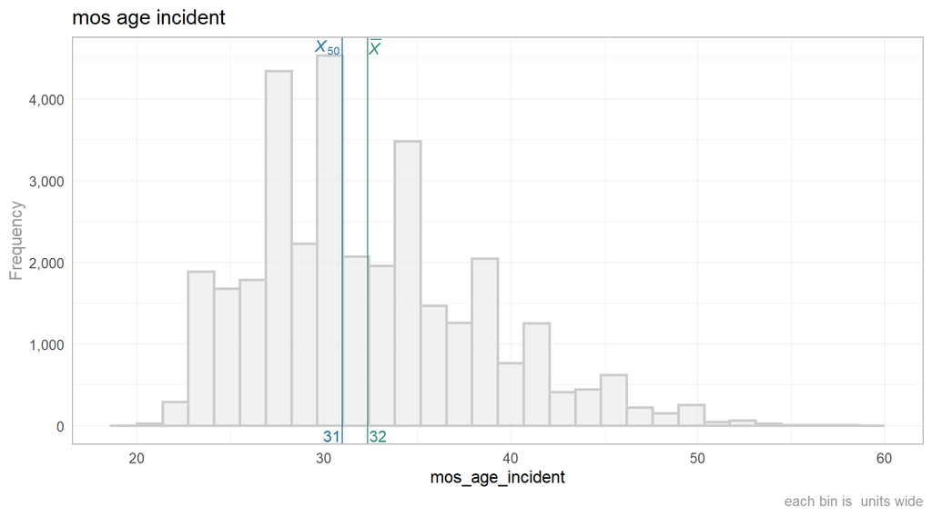

```r
# Age
ds2 %>% TabularManifest::histogram_continuous("mos_age_incident")
```

# Complainant

```r
# What is the prevalence of ethnic backgrounds
ds2 %>% counts_and_percent(c("complainant_ethnicity5","complainant_ethnicity")) %>% neat()
```

| complainant_ethnicity5 | complainant_ethnicity | n | pct |
| --- | --- | --- | --- |
| White | White | 2783 | 8.3% |
| Black | Black | 17114 | 51.3% |
| Hispanic | Hispanic | 6424 | 19.3% |
| Other | American Indian | 64 | 0.2% |
| Other | Asian | 532 | 1.6% |
| Other | Other Race | 677 | 2.0% |
| (Missing) | (Missing) | 4464 | 13.4% |
| (Missing) | Refused | 259 | 0.8% |
| (Missing) | Unknown | 1041 | 3.1% |

```r
ds2 %>% counts_and_percent(c("complainant_ethnicity5")) %>% neat()
```

| complainant_ethnicity5 | n | pct |
| --- | --- | --- |
| White | 2783 | 8.3% |
| Black | 17114 | 51.3% |
| Hispanic | 6424 | 19.3% |
| Other | 1273 | 3.8% |
| (Missing) | 5764 | 17.3% |

```r
ds2 %>% counts_and_percent(c("complainant_gender4","complainant_gender")) %>% neat()
```

| complainant_gender4 | complainant_gender | n | pct |
| --- | --- | --- | --- |
| Male | Male | 24058 | 72.1% |
| Female | Female | 5021 | 15.1% |
| Other | Gender non-conforming | 2 | 0.0% |
| Other | Transman (FTM) | 5 | 0.0% |
| Other | Transwoman (MTF) | 20 | 0.1% |
| (Missing) | (Missing) | 4195 | 12.6% |
| (Missing) | Not described | 57 | 0.2% |

```r
ds2 %>% counts_and_percent(c("complainant_gender4")) %>% neat()
```

| complainant_gender4 | n | pct |
| --- | --- | --- |
| Male | 24058 | 72.1% |
| Female | 5021 | 15.1% |
| Other | 27 | 0.1% |
| (Missing) | 4252 | 12.7% |

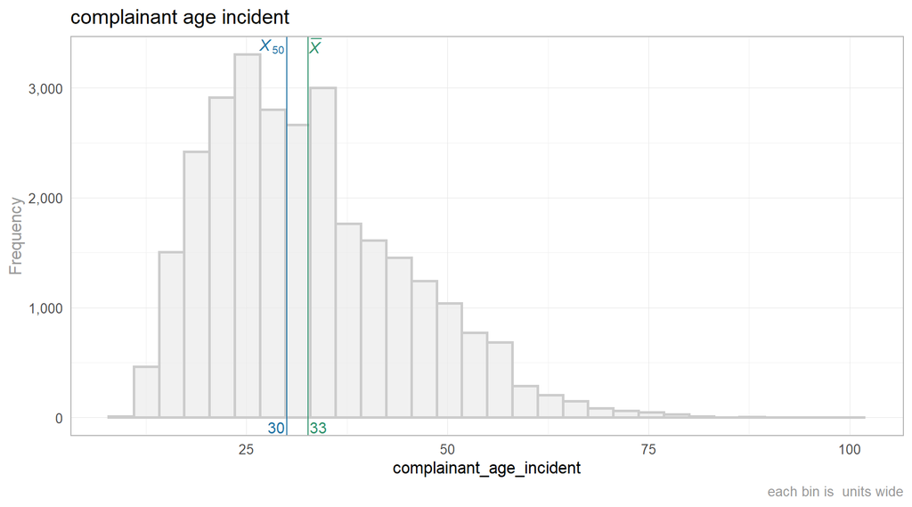

```r
ds2 %>% TabularManifest::histogram_continuous("complainant_age_incident")
```

```r
# However,
ds0 %>%
  group_by(complainant_age_incident) %>%
  summarize(n = n()) %>%
  arrange(complainant_age_incident)%>% neat_DT()
```

|  | complainant_age_incident | n |
| --- | --- | --- |
| 1 | -4301 | 1 |
| 2 | -1 | 5 |
| 3 | 0 | 2 |
| 4 | 1 | 1 |
| 5 | 2 | 2 |
| 6 | 3 | 1 |
| 7 | 6 | 1 |
| 8 | 7 | 1 |
| 9 | 8 | 3 |
| 10 | 9 | 4 |

[output cut: 80 more lines]

```r
# There appears to be some data errors in complainant age
# all records with age < 10 are transformed into NA
ds2 %>%
  group_by(complainant_age_incident) %>%
  summarize(n = n()) %>%
  arrange(complainant_age_incident)%>% neat_DT()
```

|  | complainant_age_incident | n |
| --- | --- | --- |
| 1 | 10 | 10 |
| 2 | 11 | 23 |
| 3 | 12 | 63 |
| 4 | 13 | 121 |
| 5 | 14 | 254 |
| 6 | 15 | 402 |
| 7 | 16 | 475 |
| 8 | 17 | 631 |
| 9 | 18 | 687 |
| 10 | 19 | 888 |

[output cut: 70 more lines]

```r
# ds2 %>% glimpse()
```

# Complaint

```r
ds2 %>% counts_and_percent("fado_type") %>% neat()
```

| fado_type | n | pct |
| --- | --- | --- |
| Abuse of Authority | 20292 | 60.8% |
| Discourtesy | 4677 | 14.0% |
| Force | 7636 | 22.9% |
| Offensive Language | 753 | 2.3% |

```r
ds2 %>% counts_and_percent(c("fado_type","allegation")) %>% neat_DT()
```

|  | fado_type | allegation | n | pct |
| --- | --- | --- | --- | --- |
| 1 | Abuse of Authority | Arrest/D. A. T. | 6 | 0.0% |
| 2 | Abuse of Authority | Arrest/Onlooker | 4 | 0.0% |
| 3 | Abuse of Authority | Body Cavity Searches | 3 | 0.0% |
| 4 | Abuse of Authority | Detention | 19 | 0.1% |
| 5 | Abuse of Authority | Electronic device information deletion | 11 | 0.0% |
| 6 | Abuse of Authority | Entry of Premises | 289 | 0.9% |
| 7 | Abuse of Authority | Failed to Obtain Language Interpretation | 2 | 0.0% |
| 8 | Abuse of Authority | Failure to provide RTKA card | 176 | 0.5% |
| 9 | Abuse of Authority | Forcible Removal to Hospital | 120 | 0.4% |
| 10 | Abuse of Authority | Frisk | 1926 | 5.8% |

[output cut: 109 more lines]

```r
ds2 %>% counts_and_percent(c("disposition","penalty")) %>% neat()
```

| disposition | penalty | n | pct |
| --- | --- | --- | --- |
| Exonerated | NA | 9609 | 28.8% |
| Unsubstantiated | NA | 15448 | 46.3% |
| Substantiated | Charges | 3796 | 11.4% |
| Substantiated | Command Discipline | 851 | 2.6% |
| Substantiated | Command Discipline A | 964 | 2.9% |
| Substantiated | Command Discipline B | 789 | 2.4% |
| Substantiated | Command Lvl Instructions | 454 | 1.4% |
| Substantiated | Formalized Training | 1033 | 3.1% |
| Substantiated | Instructions | 248 | 0.7% |
| Substantiated | MOS Unidentified | 1 | 0.0% |
| Substantiated | No Recommendations | 165 | 0.5% |

```r
ds2 %>% counts_and_percent(c("disposition")) %>% neat()
```

| disposition | n | pct |
| --- | --- | --- |
| Exonerated | 9609 | 28.8% |
| Unsubstantiated | 15448 | 46.3% |
| Substantiated | 8301 | 24.9% |

# Contact

```r
ds2 %>% counts_and_percent(c("contact_reason"))%>% arrange(desc(n)) %>% neat_DT()
```

|  | contact_reason | n | pct |
| --- | --- | --- | --- |
| 1 | PD suspected C/V of violation/crime - street | 10078 | 30.2% |
| 2 | Other | 4104 | 12.3% |
| 3 | PD suspected C/V of violation/crime - auto | 2981 | 8.9% |
| 4 | PD suspected C/V of violation/crime - bldg | 2542 | 7.6% |
| 5 | Moving violation | 1983 | 5.9% |
| 6 | Other violation of VTL | 1140 | 3.4% |
| 7 | Report-dispute | 1085 | 3.3% |
| 8 | Execution of search warrant | 913 | 2.7% |
| 9 | Report of other crime | 906 | 2.7% |
| 10 | Execution of arrest/bench warrant | 683 | 2.0% |

[output cut: 44 more lines]

```r
ds2 %>% counts_and_percent(c("outcome_description"))%>% arrange(desc(n)) %>% neat_DT()
```

|  | outcome_description | n | pct |
| --- | --- | --- | --- |
| 1 | No arrest made or summons issued | 12822 | 38.4% |
| 2 | Arrest - other violation/crime | 10196 | 30.6% |
| 3 | Summons - disorderly conduct | 2118 | 6.3% |
| 4 | Summons - other violation/crime | 1940 | 5.8% |
| 5 | Arrest - resisting arrest | 1593 | 4.8% |
| 6 | Arrest - disorderly conduct | 1013 | 3.0% |
| 7 | Arrest - assault (against a PO) | 852 | 2.6% |
| 8 | Moving violation summons issued | 839 | 2.5% |
| 9 | Arrest - OGA | 649 | 1.9% |
| 10 | Other VTL violation summons issued | 531 | 1.6% |

[output cut: 14 more lines]

# Product

After initial investigation and cleaning, the data that is passed to subsequent analysis contains: (click on the `Code` button to unfold)

```r
# ds2 - adjust the columns
ds2 <- ds1 %>%
  select(
  # MOS - Member of Service
    unique_mos_id            #  Unique ID of the officer
    ,mos_ethnicity           #
    ,mos_gender              #
    ,mos_age_incident        #
    ,mos_yob                 # Year of birth
    ,rank_now                # Officer's rank as of July 2020
    ,rank_incident           #  --- at the time of the incident
    ,rank_abbrev_now         # Greater granularity of rank_now
    ,rank_abbrev_incident    # Greater granularity of rank_incident
    ,command_now             # Officer's command assignment as of July 2020
    ,command_at_incident     # --- at the time of the incident
    ,first_name
    ,last_name
    ,shield_no
  # Complainant
    ,complainant_ethnicity
    ,complainant_ethnicity5   # collapsed into 5 categories
    ,complainant_gender       # original values
    ,complainant_gender4      # Collapsed into 5 categories
    ,complainant_age_incident # less than 10 converted to NA
    ,complainant_yob          # year of birth
  # Complaint
    ,complaint_id
    ,date_received           # transformed from year + month (15th of the month)
    ,date_closed             # transformed from year + month (15th of the month)
    ,fado_type               # Top-level category of complaint
    ,allegation              # Specific category of complaint
    ,precinct
    ,board_disposition       # Finding disposition
    ,disposition             # Decision        (part of board_disposition)
    ,penalty                 # Penalty applied (part of board_disposition)
  # Contact ( between MOS and the complanant)
    ,contact_reason
    ,outcome_description     # Contact outcome
  )
```

```r
ds2 %>% readr::write_rds("./data-unshared/derived/dto.rds")
ds2 %>% readr::write_rds("./data-public/derived/nypd-ccrb-cleaned.rds")
ds2 %>% readr::write_csv("./data-public/derived/nypd-ccrb-cleaned.csv")
```

# Session Information